# Case Study: Valorant Champions 2024

João Kishi

2025-02-27

# Introduction

##### The ESports gaming scene is growing exponentially over the years, and data comes in all shapes and forms when dealing with games. In this case study, we will be reviewing and analyzing data from the Valorant Champions 2024, by using tools like R and Excel, we’ll discover interesting stuff about players statistics as well as patterns and trends over the data.

##### The Valorant Champions 2024 was conquered by Edward Gaming (EDG) and the MVP was ZmjjKK

##### All data used was taken from Kaggle, from the [Valorant Champion Tour 2021-2024 Data](https://www.kaggle.com/datasets/ryanluong1/valorant-champion-tour-2021-2023-data) dataset by Ryan Luong. The data has 10.0 usability and is licensed by MIT, all data was scraped from vlr.gg.

# Loading libraries

```r
library(tidyverse)
library(ggplot2)
library(plotly)
library(dplyr)
library(readr)
library(gridExtra)
```

##### The libraries are used to process, analyze, and visualize data.

# Loading data

```r
## Load players_stats
players_stats <- read_csv("players_stats_filtered.csv")
## Load kills_stats
kills_stats <- read_csv("kills_stats_filtered.csv")
```

##### The data is loaded from two CSV files. Both datasets were cleaned in Excel, documentation [here](https://drive.google.com/file/d/1AtIxHfwjc122lhXGuWheh6NlA0RSwmPh/view?usp=sharing)

# Processing data

```r
## Clean columns names
colnames(kills_stats) <- gsub(" ", "_", colnames(kills_stats))
colnames(players_stats) <- gsub(" ", "_", colnames(players_stats))

## Define team abbreviations mapping
team_abbreviations <- c("Gen.G" = "GEN", "Sentinels" = "SEN", "FunPlus Phoenix" = "FPX",
                        "Team Heretics" = "TH", "DRX" = "DRX", "KRÜ Esports" = "KRÜ",
                        "FNATIC" = "FNC", "Bilibili Gaming" = "BLG", "LEVIATÁN" = "LEV",
                        "Talon Esports" = "TLN", "Team Vitality" = "VIT", "Trace Esports" = "TE",
                        "G2 Esports" = "G2", "Paper Rex" = "PRX", "EDward Gaming" = "EDG",
                        "FUT Esports" = "FUT")
kills_stats <- kills_stats %>%
  mutate(Team_Abbreviations = team_abbreviations[Team])
players_stats <- players_stats %>%
  mutate(Team_Abbreviations = team_abbreviations[Teams])
players_stats <- players_stats %>%
  rename(
    KAST = "Kill,_Assist,_Trade,_Survive_%",
    ADR = "Average_Damage_Per_Round",
    Clutches = "Clutches_(won/played)",
    "Clutches_%" = "Clutch_Success_%",
    ACS = "Average_Combat_Score"
  )

## Adding rounds played per player to kills stats dataset
rounds_played_per_player <- players_stats %>%
  select(Player, Rounds_Played)
kills_stats <- left_join(kills_stats, rounds_played_per_player, by = "Player")

# Creating variables for grand finals data
grand_final_data <- kills_stats[kills_stats$`Match_Type` == "Grand Final", ]
grand_final_player_data <- left_join(grand_final_data, players_stats, by = "Player")

## Verifying data integrity
### Kills stats columns names.
colnames(kills_stats)
```

```
##  [1] "Tournament"         "Stage"              "Match_Type"
##  [4] "Match_Name"         "Map"                "Team"
##  [7] "Player"             "Agents"             "2k"
## [10] "3k"                 "4k"                 "5k"
## [13] "1v1"                "1v2"                "1v3"
## [16] "1v4"                "1v5"                "Econ"
## [19] "Spike_Plants"       "Spike_Defuses"      "Team_Abbreviations"
## [22] "Rounds_Played"
```

```r
### Players stats columns names.
colnames(players_stats)
```

```
##  [1] "Tournament"                    "Stage"
##  [3] "Match_Type"                    "Player"
##  [5] "Teams"                         "Agents"
##  [7] "Rounds_Played"                 "Rating"
##  [9] "ACS"                           "Kills:Deaths"
## [11] "KAST"                          "ADR"
## [13] "Kills_Per_Round"               "Assists_Per_Round"
## [15] "First_Kills_Per_Round"         "First_Deaths_Per_Round"
## [17] "Headshot_%"                    "Clutches_%"
## [19] "Clutches"                      "Maximum_Kills_in_a_Single_Map"
## [21] "Kills"                         "Deaths"
## [23] "Assists"                       "First_Kills"
## [25] "First_Deaths"                  "Team_Abbreviations"
```

```r
### Verifying if all teams have 5 players.
print(table(players_stats$Teams))
```

```
##
## Bilibili Gaming             DRX   EDward Gaming          FNATIC FunPlus Phoenix
##               5               5               5               5               5
##     FUT Esports      G2 Esports           Gen.G     KRÜ Esports        LEVIATÁN
##               5               5               5               5               5
##       Paper Rex       Sentinels   Talon Esports   Team Heretics   Team Vitality
##               5               5               5               5               5
##   Trace Esports
##               5
```

```r
### Verifying if all players on each team have the same matches.
print(table(players_stats$`Rounds_Played`))
```

```
##
##  78  85  88 115 140 151 153 156 200 208 238 293 361 407 449 552
##   5   5   5   5   5   5   5   5   5   5   5   5   5   5   5   5
```

##### Both datasets columns were cleaned to be snake cased.

##### The “Kills Stats” dataset didn’t have an abbreviation column, so it was made one, to be easier when analyzing and visualizing.

# Analyzing the data

## Top 10 player by Rating

```r
top_10_rating <- players_stats %>%
  arrange(desc(Rating)) %>%
  head(10)
```

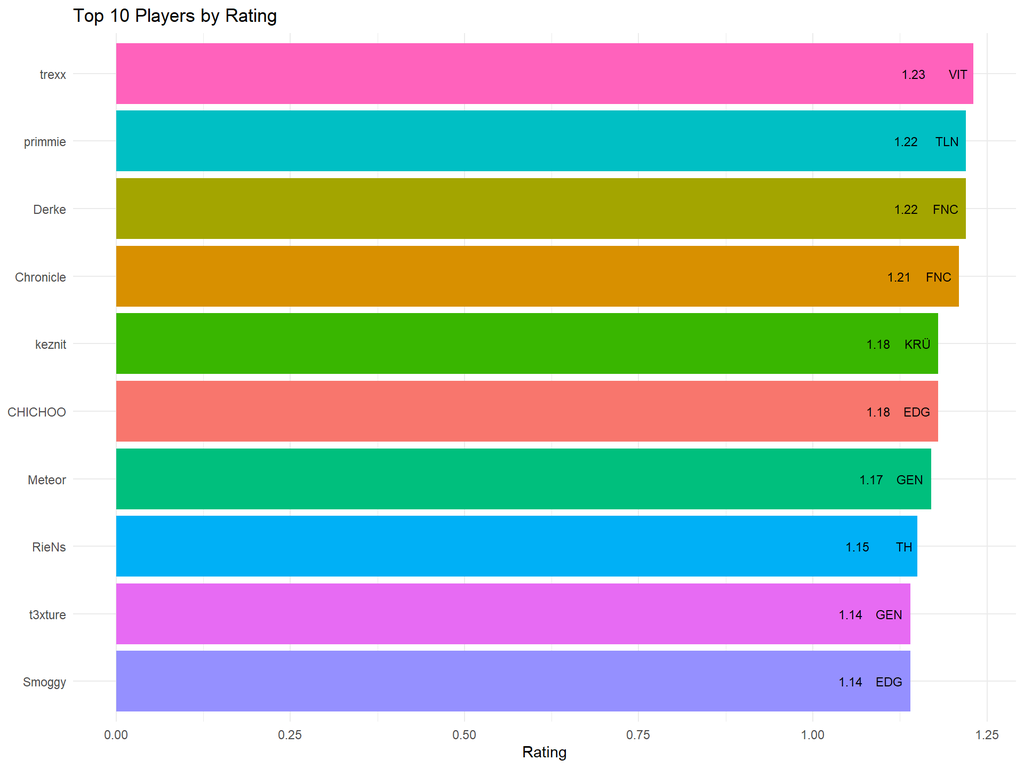

```r
ggplot(top_10_rating, aes(x = reorder(Player, Rating), y = Rating, fill = Player)) +
  geom_col() +
  coord_flip() +
  geom_text(aes(label = Team_Abbreviations), hjust = 1.3, color = "black", size = 3) +
  geom_text(aes(label = Rating), hjust = 3, color = "black", size = 3) +
  labs(title = "Top 10 Players by Rating",
       x = NULL,
       y = "Rating") +
  theme_minimal() +
  theme(legend.position = "none")
```

##### Here we can see the Top 10 players by Rating.

## Grand Finals top 10 Rating

```r
top_10_rating_grand_final <- grand_final_player_data %>%
  arrange(desc(Rating)) %>%
  head(10)
```

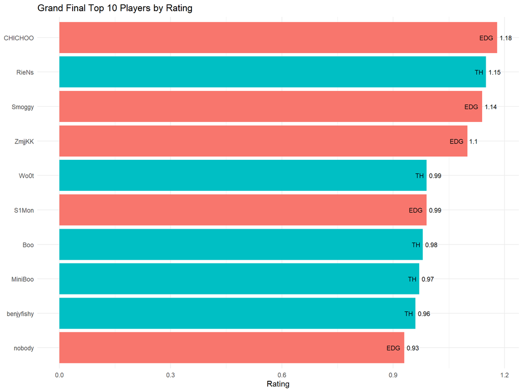

```r
ggplot(top_10_rating_grand_final, aes(x = reorder(Player, Rating), y = Rating, fill = Team_Abbreviations.y)) +
  geom_col() +
  coord_flip() +
  geom_text(aes(label = Team_Abbreviations.y), hjust = 1.3, color = "black", size = 3) +
  geom_text(aes(label = Rating), hjust = -0.2, color = "black", size = 3) +
  labs(title = "Grand Final Top 10 Players by Rating",
       x = NULL,
       y = "Rating") +
  theme_minimal() +
  theme(legend.position = "none")
```

## Creating max multikills list with players names and teams

```r
max_kills_list <- lapply(c("5k", "4k", "3k", "2k"), function(kill_type) {
  max_kill_value <- max(kills_stats[[kill_type]], na.rm = TRUE)
  max_rows_kills <- kills_stats[kills_stats[[kill_type]] == max_kill_value, ]
  data.frame(
    Kill_Type = kill_type,
    Player = max_rows_kills$Player,
    Team_Abbreviations = max_rows_kills$Team_Abbreviations,
    Max_Kills = max_rows_kills[[kill_type]],
    Rounds_Played = max_rows_kills$Rounds_Played,
    stringsAsFactors = FALSE
  )
})
max_kills <- do.call(rbind, max_kills_list)
```

```
##                Kill_Type Player Team_Abbreviations Max_Kills Rounds_Played
## EDward Gaming         5k ZmjjKK                EDG         2           449
## Gen.G                 4k Meteor                GEN         4           153
## G2 Esports            4k    icy                 G2         4           200
## EDward Gaming1        4k ZmjjKK                EDG         4           449
## LEVIATÁN              3k  aspas                LEV         8           407
## FNATIC                3k  Derke                FNC         8           293
## Team Heretics         2k  RieNs                 TH        24           552
## EDward Gaming2        2k ZmjjKK                EDG        24           449
```

##### This table contains all types of multikills (2k, 3k, 4k and 5k), the max count for each multikill each player did, their rounds played as well as their team.

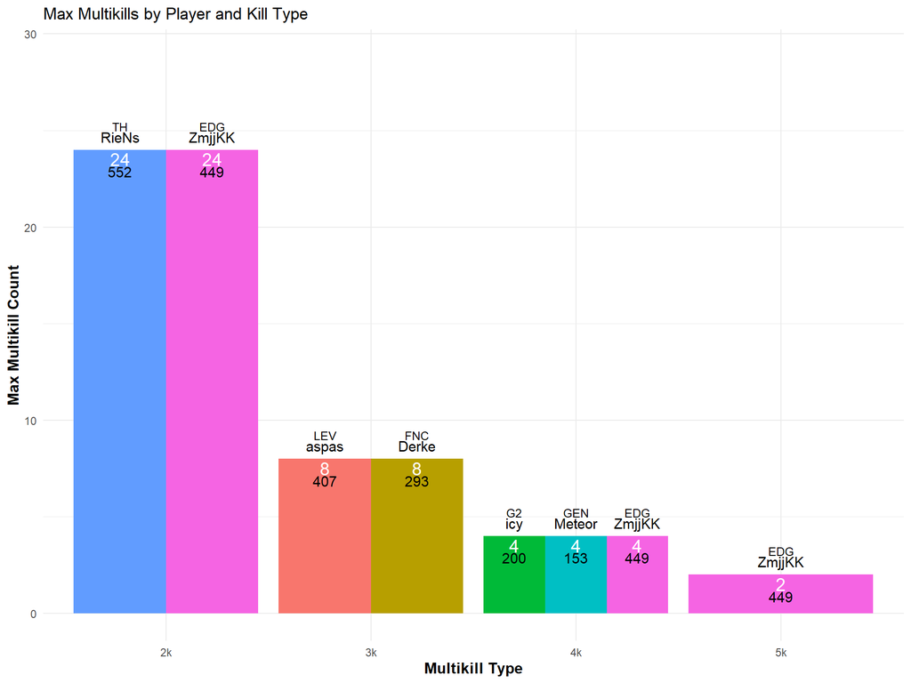

```r
ggplot(max_kills, aes(x = Kill_Type, y = Max_Kills, fill = Player)) +
  geom_bar(stat = "identity", position = "dodge", show.legend = FALSE) +
  geom_text(aes(label = Max_Kills), color = "white", size = 5, vjust = 1.2, position = position_dodge(width = 0.9)) +
  geom_text(aes(label = Team_Abbreviations), color = "black", size = 3.3, vjust = -2.1, position = position_dodge(width = 0.9)) +
  geom_text(aes(label = Player), color = "black", size = 4, vjust = -0.7, position = position_dodge(width = 0.9)) +
  geom_text(aes(label = Rounds_Played), color = "black", size = 4, vjust = 2.5, position = position_dodge(width = 0.9)) +
  scale_y_continuous(limits = c(0, max(max_kills$Max_Kills) * 1.2)) +
  theme_minimal() +
  theme(
    axis.title.x = element_text(size = 12, face = "bold"),
    axis.title.y = element_text(size = 12, face = "bold"),
    axis.title = element_text(margin = margin(10, 10, 10, 10)),
  ) +
  labs(
    title = "Max Multikills by Player and Kill Type",
    x = "Multikill Type",
    y = "Max Multikill Count"
  )
```

##### Here we can see that the MVP ZmjjKK had a remarkable impact in the tournament, leading the multikills charts and being the only player with 2 “Aces” (5k)

## Scatter plot of First Kills vs. Total Kills

```r
fk_vs_kill <- ggplot(players_stats, aes(x = Kills, y = First_Kills, color = Team_Abbreviations,
                             text = paste("Player:", Player,
                                          "<br>First Kills:", First_Kills,
                                          "<br>Total Kills:", Kills))) +
  geom_point(size = 2.3) +
  theme_minimal() +
  labs(title = "First Kills vs. Total Kills",
       x = "Total Kills",
       y = "First Kills",
       color = "Team")
fk_vs_kill_interactive <- ggplotly(fk_vs_kill, tooltip = "text") %>%
  layout(hoverlabel = list(
    bgcolor = "white",
    font = list(color = "black")
  ))
```

[interactive chart not shown]

##### The scatter plot illustrates the relationship between first kills and total kills. It shows that players in the duelist role dominate the first kill statistics, while players from the Grand Finals lead the total kills chart, likely due to having played more maps than other participants.

## General statistics

### Average Damage per Round

```r
adr <- ggplot(players_stats, aes(x = Player, y = ADR, fill = Player, text = paste("Player:", Player, "<br>ADR:", ADR))) +
  geom_bar(stat = "identity") +
  labs(title = "Average Damage per Round by Player", y = "Avg. Damage per Round") +
  theme_minimal() +
  theme(axis.text.x = element_text(angle = 90, hjust = 1))
adr_plot <- ggplotly(adr, tooltip = "text") %>%
  layout(hoverlabel = list(
    bgcolor = "white",
    font = list(color = "black")
  ))
```

[interactive chart not shown]

##### The ADR and ACS each player average performance. ADR showing the individual performance and ACS showing the impact they have on the rounds.

### Average Combat Score

```r
acs <- ggplot(players_stats, aes(x = Player, y = ACS, text = paste("Player:", Player, "<br>ACS:", ACS))) +
  geom_point(size = 2) +
  labs(title = "Average Combat Score by Player", y = "Avg. Combat Score") +
  theme_minimal() +
  theme(axis.text.x = element_text(angle = 80, hjust = 1))
acs_plot <- ggplotly(acs, tooltip = "text")%>%
    layout(hoverlabel = list(
    bgcolor = "white",
    font = list(color = "black")
  ))
```

[interactive chart not shown]